# Financial Analysis of the S&P500 for Year 2017

[figure not shown]

```python
# Picture of the SP500
from IPython.display import Image
Image(filename= 'SP-500-Visualization.png')
```

## This analysis is interested in answering how did 9 tech companies perform relative to the S&P500 Index for Year 2017.

## For the S&P500, we'll answer these questions:

#### 1,) Which ticker had the minimum adjusted closing price

#### 2.) Which ticker had the maximum adjusted closing price

#### 3.) Which ticker had the maximum trading volume

## For our 9 technology companies, we'll answer these questions:

#### 1.) What is the daily closing price

#### 2.) What is the simple daily percentage change

#### 3.) What is the daily trading volume

#### 4.) What is the daily cumulative return

#### 5.) Which correlated best & least with the S&P500 index

#### 6.) And finally, which tickers out-performed the S&P500 index

### The 9 chosen technology companies are Apple, Adobe, AMD, Facebook, F5 Networks, IBM, Google, Microsoft, and Amazon.

## To get our data, we'll scrape Yahoo Finance for all of the S&P500 financial tickers and place them into a pandas dataframe. While we could set our time frame for any number of days or years, we'll limit it to just those ones for year 2017.

```python
import pandas as pd
import numpy as np
import datetime as dt
import os
import matplotlib as mpl
import matplotlib.pyplot as plt
%matplotlib inline
import seaborn as sns #Works with matplotlib
#plt.style.use('seaborn-whitegrid')

from pandas_datareader import data as pdr
import fix_yahoo_finance as yf
yf.pdr_override() # <== that's all it takes :-)

import sys
sys.path.append('/home/kgarbutt/Dropbox/fin_project/')

import os
os.chdir('/home/kgarbutt/Dropbox/fin_project')

### Graphing code to reduce coding

# Used for graphing adusted closing Graphs
def render_daily_close(data, px_name):
    # render top graph
    data[px_name].plot()
    plt.ylabel('Ticker Adj Closing Price')
    plt.legend(loc='best')
    plt.gcf().set_size_inches(15, 8);

# Used for graphing Adjusted Close and Volume Graphs
def render_close_volume(data, data2, px_name):
    # render top graph
    plt.subplot2grid((4,4), (0,0), rowspan=3, colspan=4)
    data[px_name].plot(grid=True).xaxis.set_ticklabels([])
    plt.title('Ticker Adjusted Close Price 2017-2018')
    plt.xlabel('')
    plt.ylabel('Ticker Adjusted Closing Price')
    plt.legend(loc=2)

    # render bottom graph
    plt.subplot2grid((4,4), (3,0), rowspan=1, colspan=4)
    data2[px_name].plot(grid=True)
    plt.ylabel('Trading Volume')
    plt.subplots_adjust(hspace=0.75)
    plt.title('Ticker Trading Volume 2017-2018')
    plt.gcf().set_size_inches(15, 8)
    plt.legend(loc=2);

    # alternative bar bottom graph
    #pxV = just_Volume_px[[px_name]]
    #bottom = plt.subplot2grid((4,4), (3,0), rowspan=1, colspan=4)
    #bottom.bar(pxV.index, pxV[px_name])
    #plt.title('Ticker Trading Volume 2017 - 2018')
    #plt.ylabel('Ticker Volume')
    #plt.subplots_adjust(hspace=0.75)
    #plt.gcf().set_size_inches(15, 8)
    #plt.grid();

# Used for Graphing Daily Percentage Change Graphs
def render_dpc(data_pc, pc_name):
    daily_pc[pc_name].plot()
    plt.ylabel('Ticker Simple Daily Percentage Change')
    plt.legend(loc=2)
    plt.gcf().set_size_inches(15, 5);

# Used for graphing Scatter Plot Graphs
def render_scatter_plot(data, x_stock_name, y_stock_name, xlim=None, ylim=None):
    fig = plt.figure(figsize=(15, 8))
    ax = fig.add_subplot(111)
    ax.scatter(data[x_stock_name], data[y_stock_name])
    if xlim is not None: ax.set_xlim(xlim)
    ax.autoscale(False)
    ax.vlines(0, -10, 10)
    ax.hlines(0, -10, 10)
    ax.plot((-10, 10), (-10, 10))
    ax.set_xlabel(x_stock_name)
    ax.set_ylabel(y_stock_name);

### Use ; at end of command to suppress output
```

```python
os.getcwd()
```

```
'/home/kgarbutt/Dropbox/fin_project'
```

### Get data for the S&P500 Analysis from Yahoo Finance

```python
def get(tickers, start, end):
    def data(ticker):
        return pdr.get_data_yahoo(ticker, start, end)
    datas = map(data, tickers)
    return pd.concat(datas, keys=tickers, names=['Ticker', 'Date'])

### Get two tickers
#tickers = ['NRG', 'NVDA']

### Get all 505 tickers
### len(tickers) = 505
### Not sure if ticker names are up to date

tickers = ['MMM','ABT','ABBV','ACN','ATVI','AYI','ADBE','AMD','AAP','AES','AET',
        'AMG','AFL','A','APD','AKAM','ALK','ALB','ARE','ALXN','ALGN','ALLE',
        'AGN','ADS','LNT','ALL','GOOGL','GOOG','MO','AMZN','AEE','AAL','AEP',
        'AXP','AIG','AMT','AWK','AMP','ABC','AME','AMGN','APH','APC','ADI','ANDV',
        'ANSS','ANTM','AON','AOS','APA','AIV','AAPL','AMAT','APTV','ADM','ARNC',
        'AJG','AIZ','T','ADSK','ADP','AZO','AVB','AVY','BHGE','BLL','BAC','BK',
        'BAX','BBT','BDX','BRK.B','BBY','BIIB','BLK','HRB','BA','BWA','BXP','BSX',
        'BHF','BMY','AVGO','BF.B','CHRW','CA','COG','CDNS','CPB','COF','CAH','CBOE',
        'KMX','CCL','CAT','CBG','CBS','CELG','CNC','CNP','CTL','CERN','CF','SCHW',
        'CHTR','CHK','CVX','CMG','CB','CHD','CI','XEC','CINF','CTAS','CSCO','C','CFG',
        'CTXS','CLX','CME','CMS','KO','CTSH','CL','CMCSA','CMA','CAG','CXO','COP',
        'ED','STZ','COO','GLW','COST','COTY','CCI','CSRA','CSX','CMI','CVS','DHI',
        'DHR','DRI','DVA','DE','DAL','XRAY','DVN','DLR','DFS','DISCA','DISCK','DISH',
        'DG','DLTR','D','DOV','DWDP','DPS','DTE','DRE','DUK','DXC','ETFC','EMN','ETN',
        'EBAY','ECL','EIX','EW','EA','EMR','ETR','EVHC','EOG','EQT','EFX','EQIX','EQR',
        'ESS','EL','ES','RE','EXC','EXPE','EXPD','ESRX','EXR','XOM','FFIV','FB','FAST',
        'FRT','FDX','FIS','FITB','FE','FISV','FLIR','FLS','FLR','FMC','FL','F','FTV',
        'FBHS','BEN','FCX','GPS','GRMN','IT','GD','GE','GGP','GIS','GM','GPC','GILD',
        'GPN','GS','GT','GWW','HAL','HBI','HOG','HRS','HIG','HAS','HCA','HCP','HP','HSIC',
        'HSY','HES','HPE','HLT','HOLX','HD','HON','HRL','HST','HPQ','HUM','HBAN','HII',
        'IDXX','INFO','ITW','ILMN','IR','INTC','ICE','IBM','INCY','IP','IPG','IFF','INTU',
        'ISRG','IVZ','IQV','IRM','JEC','JBHT','SJM','JNJ','JCI','JPM','JNPR','KSU','K','KEY',
        'KMB','KIM','KMI','KLAC','KSS','KHC','KR','LB','LLL','LH','LRCX','LEG','LEN','LUK',
        'LLY','LNC','LKQ','LMT','L','LOW','LYB','MTB','MAC','M','MRO','MPC','MAR','MMC','MLM',
        'MAS','MA','MAT','MKC','MCD','MCK','MDT','MRK','MET','MTD','MGM','KORS','MCHP','MU',
        'MSFT','MAA','MHK','TAP','MDLZ','MON','MNST','MCO','MS','MOS','MSI','MYL','NDAQ',
        'NOV','NAVI','NTAP','NFLX','NWL','NFX','NEM','NWSA','NWS','NEE','NLSN','NKE','NI',
        'NBL','JWN','NSC','NTRS','NOC','NCLH','NRG','NUE','NVDA','ORLY','OXY','OMC','OKE',
        'ORCL','PCAR','PKG','PH','PDCO','PAYX','PYPL','PNR','PBCT','PEP','PKI','PRGO','PFE',
        'PCG','PM','PSX','PNW','PXD','PNC','RL','PPG','PPL','PX','PCLN','PFG','PG','PGR',
        'PLD','PRU','PEG','PSA','PHM','PVH','QRVO','PWR','QCOM','DGX','RRC','RJF','RTN','O',
        'RHT','REG','REGN','RF','RSG','RMD','RHI','ROK','COL','ROP','ROST','RCL','CRM','SBAC',
        'SCG','SLB','SNI','STX','SEE','SRE','SHW','SIG','SPG','SWKS','SLG','SNA','SO','LUV',
        'SPGI','SWK','SBUX','STT','SRCL','SYK','STI','SYMC','SYF','SNPS','SYY','TROW','TPR',
        'TGT','TEL','FTI','TXN','TXT','TMO','TIF','TWX','TJX','TMK','TSS','TSCO','TDG','TRV',
        'TRIP','FOXA','FOX','TSN','UDR','ULTA','USB','UAA','UA','UNP','UAL','UNH','UPS','URI',
        'UTX','UHS','UNM','VFC','VLO','VAR','VTR','VRSN','VRSK','VZ','VRTX','VIAB','V','VNO',
        'VMC','WMT','WBA','DIS','WM','WAT','WEC','WFC','HCN','WDC','WU','WRK','WY','WHR','WMB',
        'WLTW','WYN','WYNN','XEL','XRX','XLNX','XL','XYL','YUM','ZBH','ZION','ZTS']

### Set time frame for download
start = dt.date(2017, 1, 1)
end = dt.date(2017, 12, 31)

## Get all tickers
### Uncomment to Run
#all_sp500 = get(tickers, start, end)

## Save to csv file
### Uncomment to Run
#all_sp500.to_csv("all_sp500.csv")
```

```python
len(tickers)
```

```
505
```

```python
# data = pd.read_csv('/home/kgarbutt/Dropbox/fin_project/all_sp500.csv', index_col='Date')
data = pd.read_csv('/home/kgarbutt/Dropbox/fin_project/all_sp500.csv')
#data.head()
data.tail()
```

|  | Ticker | Date | Adj Close | Close | High | Low | Open | Volume |
| --- | --- | --- | --- | --- | --- | --- | --- | --- |
| 125869 | ZTS | 2017-12-22 | 71.766502 | 71.989998 | 72.370003 | 71.790001 | 72.269997 | 1345700.0 |
| 125870 | ZTS | 2017-12-26 | 72.115417 | 72.339996 | 72.550003 | 71.900002 | 72.400002 | 791900.0 |
| 125871 | ZTS | 2017-12-27 | 72.225075 | 72.449997 | 72.690002 | 72.250000 | 72.589996 | 1159800.0 |
| 125872 | ZTS | 2017-12-28 | 72.165268 | 72.389999 | 72.599998 | 72.139999 | 72.489998 | 710500.0 |
| 125873 | ZTS | 2017-12-29 | 71.816353 | 72.040001 | 72.760002 | 72.040001 | 72.550003 | 1704100.0 |

```python
# Convert Date column to pd datetime format
data['Date']=pd.to_datetime(data.Date)
data.dtypes
#data.Date.dt.dayofyear.tail()
#data.Date.dt.month.tail()
```

```
Ticker               object
Date         datetime64[ns]
Adj Close           float64
Close               float64
High                float64
Low                 float64
Open                float64
Volume              float64
dtype: object
```

```python
# Get number of daily entries for each stock
#data[data['Ticker'] == 'MMM'].count()
data.groupby('Ticker').count().head()
#data.groupby('Ticker').count().tail()
```

| Ticker | Date | Adj Close | Close | High | Low | Open | Volume |
| --- | --- | --- | --- | --- | --- | --- | --- |
| A | 251 | 251 | 251 | 251 | 251 | 251 | 251 |
| AAL | 251 | 251 | 251 | 251 | 251 | 251 | 251 |
| AAP | 251 | 251 | 251 | 251 | 251 | 251 | 251 |
| AAPL | 251 | 251 | 251 | 251 | 251 | 251 | 251 |
| ABBV | 251 | 251 | 251 | 251 | 251 | 251 | 251 |

```python
# Calculate the total number of individual stocks scraped from the web
print('Number of individual tickers: ', round(len(data)/251))
```

```
Number of individual tickers:  501
```

### Select for The Adjusted Close Price for each S&P500 Ticker

#### The adjusted closing price is a stock's closing price on any given day of trading.

```python
# Select just the Ticker, Date, Adj Close columns, and reset the index
just_closing_prices = data[['Ticker', 'Date', 'Adj Close']].reset_index(drop=True)
#just_closing_prices.head()
just_closing_prices.tail()
```

|  | Ticker | Date | Adj Close |
| --- | --- | --- | --- |
| 125869 | ZTS | 2017-12-22 | 71.766502 |
| 125870 | ZTS | 2017-12-26 | 72.115417 |
| 125871 | ZTS | 2017-12-27 | 72.225075 |
| 125872 | ZTS | 2017-12-28 | 72.165268 |
| 125873 | ZTS | 2017-12-29 | 71.816353 |

```python
# Pivot the pandas.df so that tickers are in the columns
daily_close_px = just_closing_prices.pivot('Date', 'Ticker', 'Adj Close')
daily_close_px.head()
#daily_close_px.tail()
```

| Ticker Date | A | AAL | AAP | AAPL | ABBV | ABC | ABT | ACN | ADBE | ADI | ... | XL | XLNX | XOM | XRAY | XRX | XYL | YUM | ZBH | ZION | ZTS |
| --- | --- | --- | --- | --- | --- | --- | --- | --- | --- | --- | --- | --- | --- | --- | --- | --- | --- | --- | --- | --- | --- |
| 2017-01-03 | 45.972095 | 45.816048 | 170.149277 | 113.847588 | 59.171120 | 80.855629 | 37.800980 | 113.159943 | 103.480003 | 70.577919 | ... | 36.754684 | 57.513256 | 86.670731 | 58.194111 | 26.776104 | 48.875042 | 61.848686 | 102.286278 | 42.586201 | 53.041107 |
| 2017-01-04 | 46.575294 | 46.211864 | 171.545578 | 113.720169 | 60.005451 | 82.862099 | 38.101067 | 113.432007 | 104.139999 | 70.431915 | ... | 36.881325 | 57.094593 | 85.717155 | 58.670620 | 27.786526 | 49.603493 | 62.073734 | 103.226669 | 43.197666 | 53.555786 |
| 2017-01-05 | 46.021538 | 45.410336 | 171.425888 | 114.298470 | 60.460541 | 81.902901 | 38.430191 | 111.731606 | 105.910004 | 69.419624 | ... | 36.462440 | 56.403301 | 84.439362 | 57.906219 | 27.669937 | 49.150669 | 62.279213 | 103.889900 | 42.497433 | 53.377625 |
| 2017-01-06 | 47.455383 | 45.726990 | 169.181839 | 115.572701 | 60.479500 | 82.999115 | 39.475647 | 113.004478 | 108.300003 | 69.692154 | ... | 36.423473 | 57.493786 | 84.391678 | 57.866512 | 27.242453 | 48.806137 | 63.032623 | 103.899803 | 42.773582 | 53.545883 |
| 2017-01-09 | 47.603706 | 46.587898 | 169.082108 | 116.631287 | 60.877705 | 83.664673 | 39.436928 | 111.741318 | 108.570000 | 70.023102 | ... | 35.809757 | 57.503525 | 82.999451 | 58.045204 | 27.087002 | 48.599411 | 63.208744 | 105.919205 | 42.310047 | 53.397427 |

5 rows × 502 columns

### Find the S&P500's Ticker with the lowest & highest adjusted close price and graph them:

```python
# Locate the ajusted cose minimum ticker
data['Adj Close'].min()
data['Adj Close'].idxmin(axis=1)
data[25715:25716]
```

|  | Ticker | Date | Adj Close | Close | High | Low | Open | Volume |
| --- | --- | --- | --- | --- | --- | --- | --- | --- |
| 25715 | CHK | 2017-12-15 | 3.51 | 3.51 | 3.69 | 3.5 | 3.66 | 42186800.0 |

```python
# Locate the adjusted close maximum ticker
data['Adj Close'].max()
data['Adj Close'].idxmax(axis=1)
data[93896:93897]
```

|  | Ticker | Date | Adj Close | Close | High | Low | Open | Volume |
| --- | --- | --- | --- | --- | --- | --- | --- | --- |
| 93896 | PCLN | 2017-08-08 | 2049.0 | 2049.0 | 2067.98999 | 2035.109985 | 2044.0 | 830600.0 |

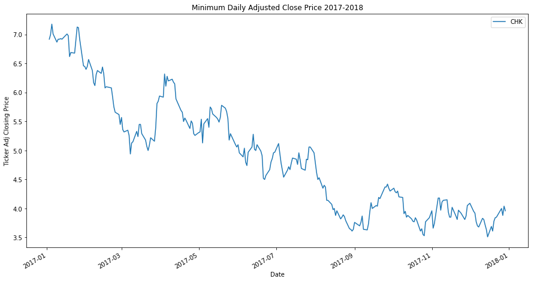

```python
# Graph S&P500's lowest adjusted close ticker
render_daily_close(daily_close_px, 'CHK')
plt.title('Minimum Daily Adjusted Close Price 2017-2018');
```

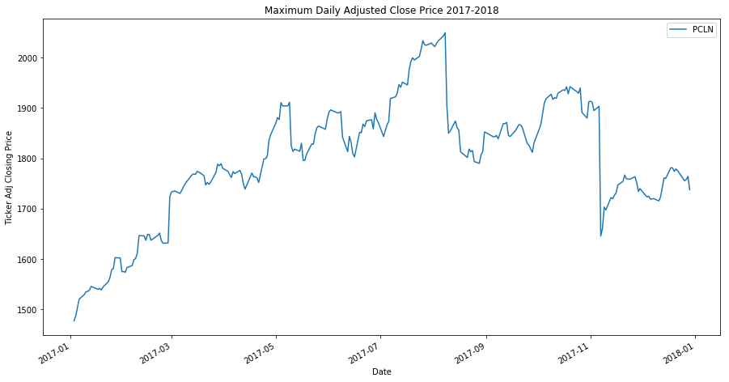

```python
# Graph S&P500's highest adjusted close ticker
render_daily_close(daily_close_px, 'PCLN')
plt.title('Maximum Daily Adjusted Close Price 2017-2018');
```

##### ADBE = Adobe Systems Incorporated

##### AMD = Advance Micro Devices, Inc

##### FFIV = F5 Networks

##### GOOG = Alphabet Inc (Google)

##### MSFT = Microsoft Corporation

##### AMZN = Amazon.com, Inc

```python
### Limit the analysis to 9 technology companies
just_tech_co = daily_close_px[['AAPL', 'ADBE', 'AMD', 'FB', 'FFIV', 'IBM', 'GOOG', 'MSFT', 'AMZN']]
just_tech_co.head()
```

| Ticker Date | AAPL | ADBE | AMD | FB | FFIV | IBM | GOOG | MSFT | AMZN |
| --- | --- | --- | --- | --- | --- | --- | --- | --- | --- |
| 2017-01-03 | 113.847588 | 103.480003 | 11.43 | 116.860001 | 144.800003 | 159.378235 | 786.140015 | 60.926991 | 753.669983 |
| 2017-01-04 | 113.720169 | 104.139999 | 11.43 | 118.690002 | 145.460007 | 161.351501 | 786.900024 | 60.654381 | 757.179993 |
| 2017-01-05 | 114.298470 | 105.910004 | 11.24 | 120.669998 | 144.419998 | 160.817673 | 794.020020 | 60.654381 | 780.450012 |
| 2017-01-06 | 115.572701 | 108.300003 | 11.32 | 123.410004 | 144.449997 | 161.608887 | 806.150024 | 61.180119 | 795.989990 |
| 2017-01-09 | 116.631287 | 108.570000 | 11.49 | 124.900002 | 144.149994 | 159.816727 | 806.650024 | 60.985405 | 796.919983 |

```python
# Display some statistics on their 'Adj Close' for our tech companies
just_tech_co.describe()
```

| Ticker | AAPL | ADBE | AMD | FB | FFIV | IBM | GOOG | MSFT | AMZN |
| --- | --- | --- | --- | --- | --- | --- | --- | --- | --- |
| count | 251.000000 | 251.000000 | 251.000000 | 251.000000 | 251.000000 | 251.000000 | 251.000000 | 251.000000 | 251.000000 |
| mean | 148.903352 | 143.996136 | 12.411673 | 156.576175 | 129.597729 | 153.098338 | 921.780837 | 70.945254 | 968.167012 |
| std | 15.111322 | 21.169879 | 1.356230 | 17.379058 | 9.588692 | 10.470946 | 77.232561 | 7.346811 | 106.580208 |
| min | 113.720169 | 103.480003 | 9.750000 | 116.860001 | 115.559998 | 136.968918 | 786.140015 | 60.654381 | 753.669983 |
| 25% | 139.606492 | 129.599999 | 11.200000 | 141.000000 | 120.379998 | 145.165466 | 836.994995 | 64.087898 | 889.024994 |
| 50% | 150.784286 | 143.619995 | 12.630000 | 153.610001 | 128.949997 | 150.359589 | 929.570007 | 70.090034 | 967.989990 |
| 75% | 158.595932 | 153.844994 | 13.525000 | 171.974998 | 136.864998 | 161.084587 | 972.759979 | 74.459529 | 1002.970001 |
| max | 175.703629 | 185.399994 | 15.200000 | 183.029999 | 148.789993 | 174.820038 | 1077.140015 | 86.443932 | 1195.829956 |

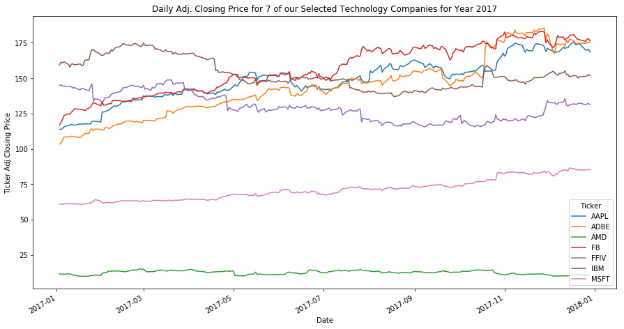

```python
# Plot the daily adjusted closing price for 7 of our tech companies
#just_tech_co.plot()
daily_close_px[['AAPL', 'ADBE', 'AMD', 'FB', 'FFIV', 'IBM', 'MSFT']].plot()
plt.title('Daily Adj. Closing Price for 7 of our Selected Technology Companies for Year 2017')
plt.ylabel('Ticker Adj Closing Price')
#plt.legend(loc='best')
plt.gcf().set_size_inches(15, 8);
```

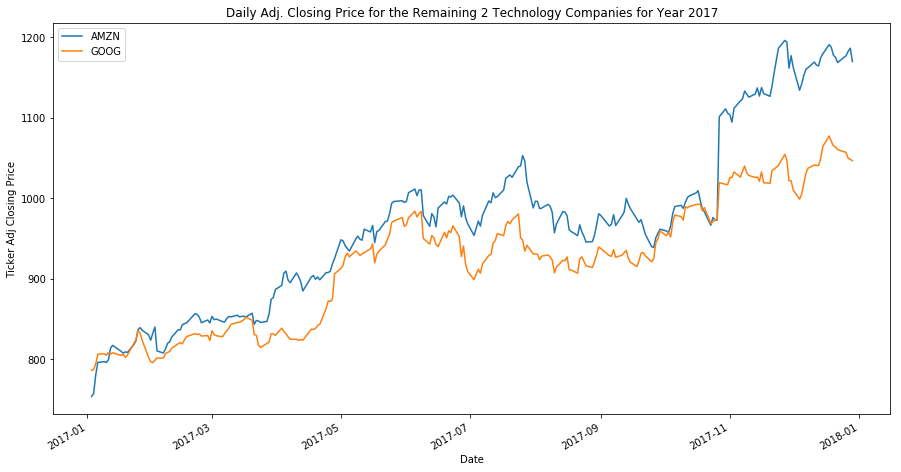

```python
# Plot the daily adjusted closing price for AMZN & GOOG
# Their closing prices was much higher than the other 7
daily_close_px[['AMZN', 'GOOG']].plot()
plt.title('Daily Adj. Closing Price for the Remaining 2 Technology Companies for Year 2017')
plt.ylabel('Ticker Adj Closing Price')
plt.legend(loc='best')
plt.gcf().set_size_inches(15, 8);
```

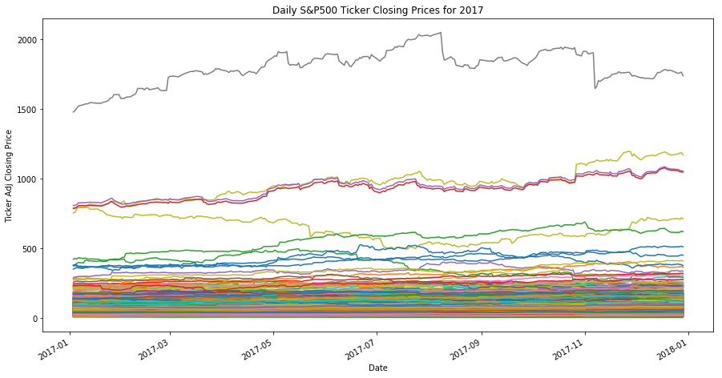

```python
# Plot All 501 S&P500 Ticker Closing Price for Year 2017
# Not practical to have a legend here so turn it off
daily_close_px.plot(legend=False)
plt.title('Daily S&P500 Ticker Closing Prices for 2017')
plt.ylabel('Ticker Adj Closing Price')
plt.gcf().set_size_inches(15, 8);
#plt.legend(loc='best')
```

### Select for The Trading Volume for each S&P500 Ticker

#### The volume, or trading volume, is the amount (total number) for a ticker that was traded during a given period of time. In our case, our period is daily.

```python
# Select just the Ticker, Date, Volume columns, and reset the index
just_Volume = data[['Ticker', 'Date', 'Volume']].reset_index(drop=True)
#just_Volume.head()
just_Volume.tail()
```

|  | Ticker | Date | Volume |
| --- | --- | --- | --- |
| 125869 | ZTS | 2017-12-22 | 1345700.0 |
| 125870 | ZTS | 2017-12-26 | 791900.0 |
| 125871 | ZTS | 2017-12-27 | 1159800.0 |
| 125872 | ZTS | 2017-12-28 | 710500.0 |
| 125873 | ZTS | 2017-12-29 | 1704100.0 |

```python
# Pivot the pandas.df so that tickers are in the columns
just_Volume_px = just_Volume.pivot('Date', 'Ticker', 'Volume')
just_Volume_px.head()
#just_Volume_px.tail()
```

| Ticker Date | A | AAL | AAP | AAPL | ABBV | ABC | ABT | ACN | ADBE | ADI | ... | XL | XLNX | XOM | XRAY | XRX | XYL | YUM | ZBH | ZION | ZTS |
| --- | --- | --- | --- | --- | --- | --- | --- | --- | --- | --- | --- | --- | --- | --- | --- | --- | --- | --- | --- | --- | --- |
| 2017-01-03 | 1739600.0 | 6737800.0 | 691300.0 | 28781900.0 | 9328200.0 | 4134200.0 | 9677300.0 | 2351600.0 | 2277400.0 | 2687200.0 | ... | 1867300.0 | 4127000.0 | 10360600.0 | 1778000.0 | 64447600.0 | 1596700.0 | 4793400.0 | 1381100.0 | 2896200.0 | 3579700.0 |
| 2017-01-04 | 1821300.0 | 5859600.0 | 641700.0 | 21118100.0 | 8674800.0 | 2561900.0 | 22644500.0 | 2639800.0 | 1712600.0 | 1971000.0 | ... | 1600700.0 | 3281700.0 | 9434200.0 | 978300.0 | 30748400.0 | 1703000.0 | 2835200.0 | 1502800.0 | 1907500.0 | 3316300.0 |
| 2017-01-05 | 1503700.0 | 6825300.0 | 861000.0 | 22193600.0 | 5359400.0 | 2136200.0 | 12080100.0 | 3685400.0 | 2504000.0 | 2067300.0 | ... | 1210500.0 | 2198000.0 | 14443200.0 | 1114500.0 | 28241100.0 | 1846000.0 | 4040000.0 | 1453900.0 | 2106000.0 | 2469100.0 |
| 2017-01-06 | 2883400.0 | 7260200.0 | 828000.0 | 31751900.0 | 4722300.0 | 2132000.0 | 14628900.0 | 4125300.0 | 2625600.0 | 2069700.0 | ... | 1214800.0 | 2381800.0 | 16518100.0 | 1169600.0 | 24684500.0 | 1561600.0 | 2863800.0 | 1821000.0 | 2149100.0 | 2845800.0 |
| 2017-01-09 | 2575300.0 | 4704600.0 | 560100.0 | 33561900.0 | 8784800.0 | 2072200.0 | 10983200.0 | 2550800.0 | 2925000.0 | 2399500.0 | ... | 1414300.0 | 3548500.0 | 13688100.0 | 950600.0 | 15209000.0 | 1090400.0 | 1935900.0 | 1128100.0 | 2104900.0 | 2123300.0 |

5 rows × 502 columns

### Find the S&P500's ticker with the highest trading volume and graph it:

```python
# Locate the SP500 ticker with the highest trading volume
just_Volume['Volume'].max()
just_Volume['Volume'].idxmax(axis=1)
just_Volume[52550:52551]
```

|  | Ticker | Date | Volume |
| --- | --- | --- | --- |
| 52550 | GE | 2017-11-14 | 312556800.0 |

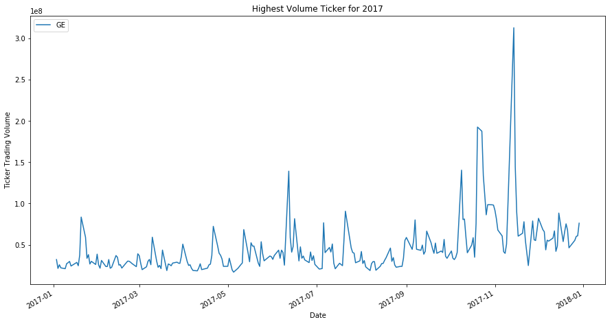

```python
# Plot the ticker with the highest trading volume

just_Volume_px[['GE']].plot()
plt.title('Highest Volume Ticker for 2017')
plt.ylabel('Ticker Trading Volume')
plt.legend(loc=2)
plt.gcf().set_size_inches(15, 8);
```

### Plot the adjusted close and trading volume for our 9 selected technology companys

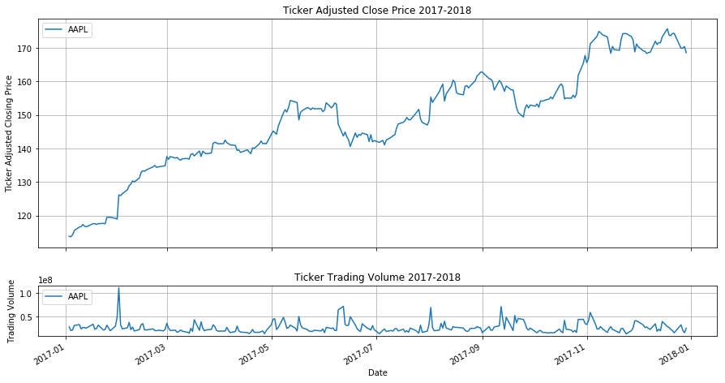

```python
# Plot Apple's Adjusted Close Price and Volume Graphs
render_close_volume(daily_close_px, just_Volume_px, 'AAPL')
```

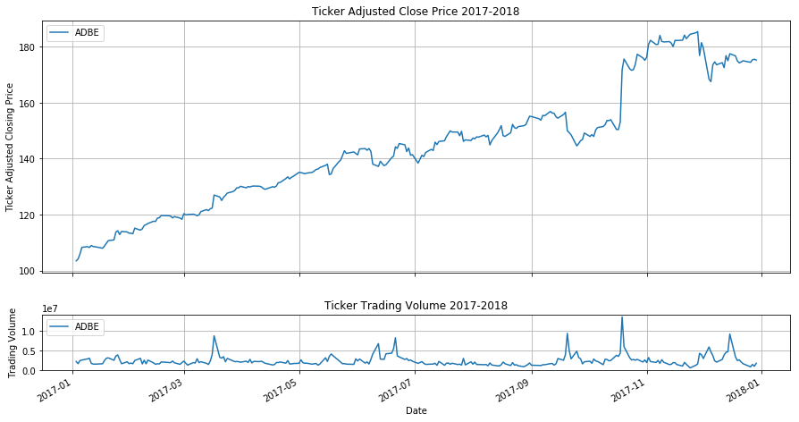

```python
# Plot Adobe's Adjusted Close Price and Volume Graphs
render_close_volume(daily_close_px, just_Volume_px, 'ADBE')
```

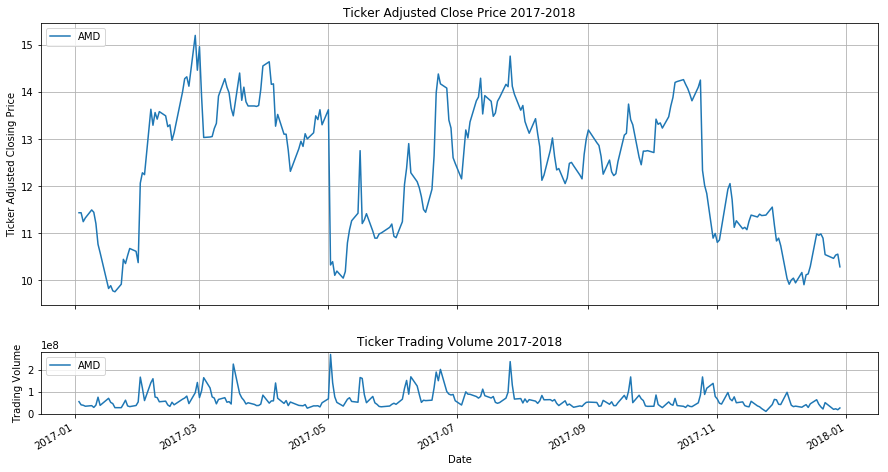

```python
# Plot AMD's Adjusted Close Price and Volume Graphs
render_close_volume(daily_close_px, just_Volume_px, 'AMD')
```

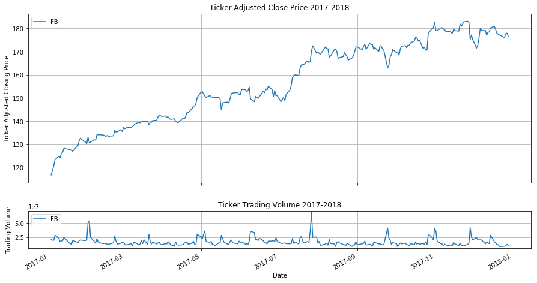

```python
# Plot Facebook's Adjusted Close Price and Volume Graphs
render_close_volume(daily_close_px, just_Volume_px, 'FB')
```

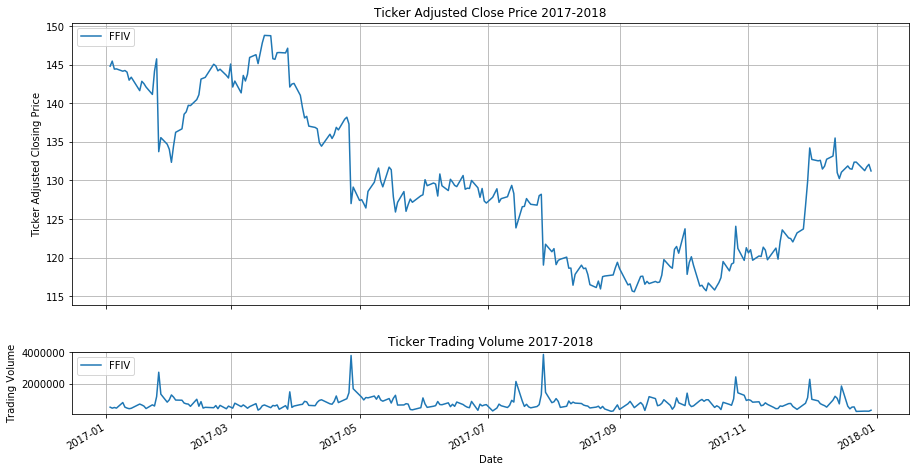

```python
# Plot FFIV's Adjusted Close Price and Volume Graphs
render_close_volume(daily_close_px, just_Volume_px, 'FFIV')
```

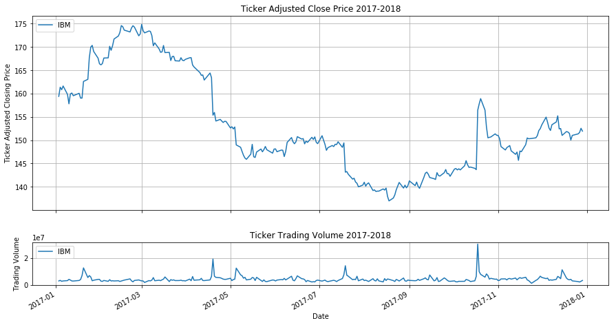

```python
# Plot IBM's Adjusted Close Price and Volume Graphs
render_close_volume(daily_close_px, just_Volume_px, 'IBM')
```

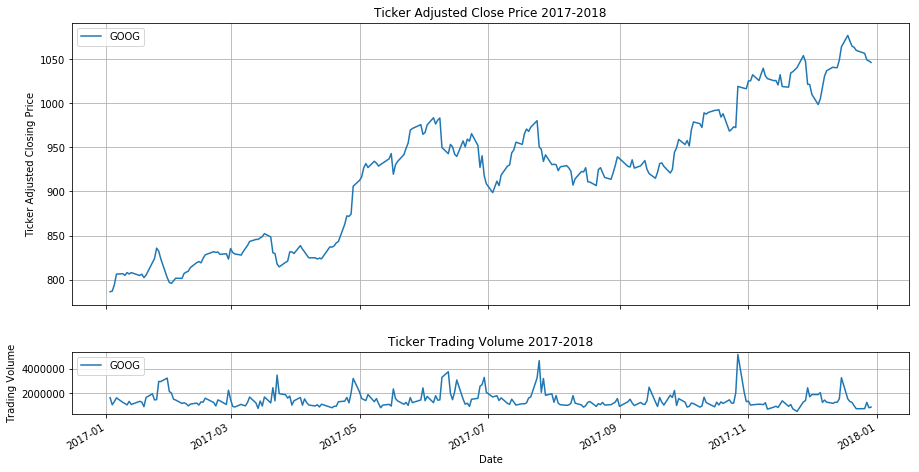

```python
# Plot Google's Adjusted Close Price and Volume Graphs
render_close_volume(daily_close_px, just_Volume_px, 'GOOG')
```

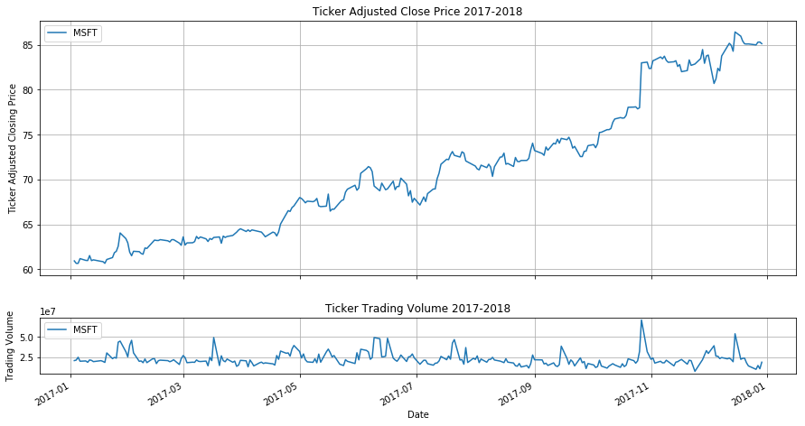

```python
# Plot Microsoft's Adjusted Close Price and Volume Graphs
render_close_volume(daily_close_px, just_Volume_px, 'MSFT')
```

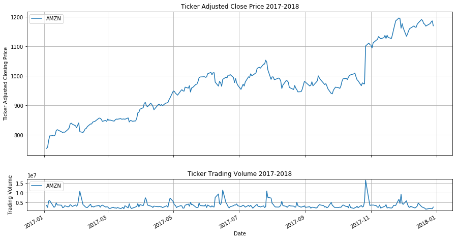

```python
# Plot Amazon's Adjusted Close Price and Volume Graphs
render_close_volume(daily_close_px, just_Volume_px, 'AMZN')
```

### Calculate Simple Daily Percentage Change for Selected Technology Companies

#### The simple daily percentage change is the amount of percentage change in the value of a stock over a single day of trading.

```python
# calculate the daily percentage change (1st way) for tech companies
daily_pc = just_tech_co / just_tech_co.shift(1) - 1
daily_pc.fillna(0, inplace=True)
# daily_pc2 = daily_close_px.pct_change().fillna(0) ### (2nd way but for all S&P500)
daily_pc[:5]
#daily_pc.iloc[:,0:2][:5]
```

| Ticker Date | AAPL | ADBE | AMD | FB | FFIV | IBM | GOOG | MSFT | AMZN |
| --- | --- | --- | --- | --- | --- | --- | --- | --- | --- |
| 2017-01-03 | 0.000000 | 0.000000 | 0.000000 | 0.000000 | 0.000000 | 0.000000 | 0.000000 | 0.000000 | 0.000000 |
| 2017-01-04 | -0.001119 | 0.006378 | 0.000000 | 0.015660 | 0.004558 | 0.012381 | 0.000967 | -0.004474 | 0.004657 |
| 2017-01-05 | 0.005085 | 0.016996 | -0.016623 | 0.016682 | -0.007150 | -0.003308 | 0.009048 | 0.000000 | 0.030732 |
| 2017-01-06 | 0.011148 | 0.022566 | 0.007117 | 0.022707 | 0.000208 | 0.004920 | 0.015277 | 0.008668 | 0.019912 |
| 2017-01-09 | 0.009159 | 0.002493 | 0.015018 | 0.012074 | -0.002077 | -0.011089 | 0.000620 | -0.003183 | 0.001168 |

```python
# Show this calculation for Apple
aapl_t1 = daily_pc.iloc[1]['AAPL'] #Pt-1
aapl_t2 = daily_pc.iloc[2]['AAPL'] #Pt
r_t1 = aapl_t2 / aapl_t1 - 1 # returns

aapl_t1, aapl_t2, r_t1
```

```
(-0.0011192068469645378, 0.005085298457479404, -5.54366274766056)
```

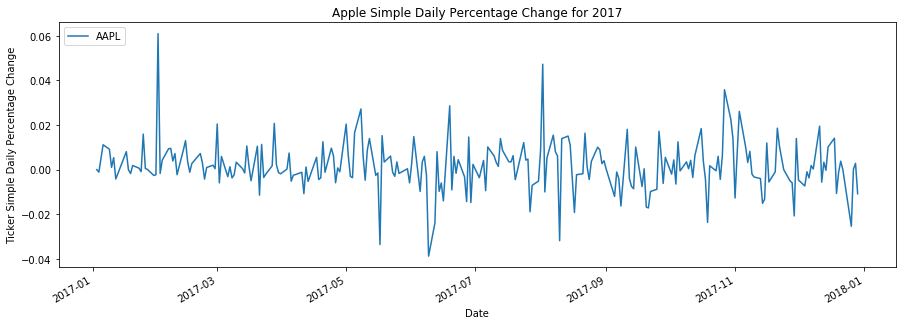

```python
render_dpc(daily_pc, 'AAPL')
plt.title('Apple Simple Daily Percentage Change for 2017');
```

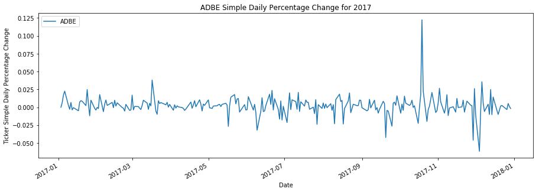

```python
render_dpc(daily_pc, 'ADBE')
plt.title('ADBE Simple Daily Percentage Change for 2017');
```

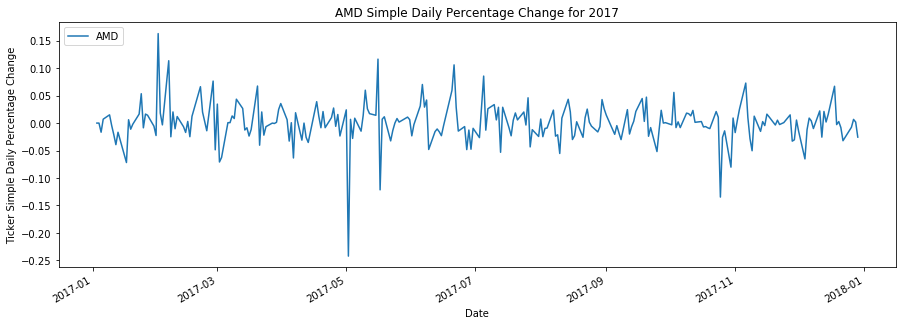

```python
render_dpc(daily_pc, 'AMD')
plt.title('AMD Simple Daily Percentage Change for 2017');
```

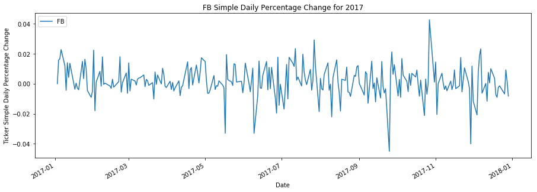

```python
render_dpc(daily_pc, 'FB')
plt.title('FB Simple Daily Percentage Change for 2017');
```

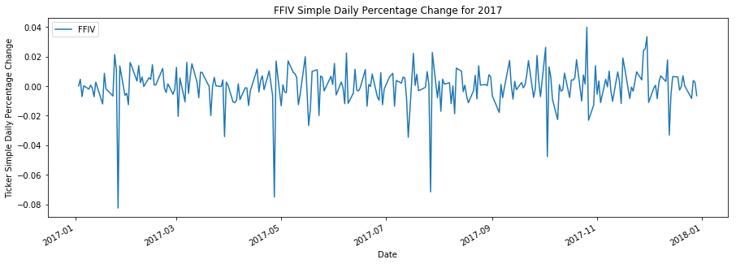

```python
render_dpc(daily_pc, 'FFIV')
plt.title('FFIV Simple Daily Percentage Change for 2017');
```

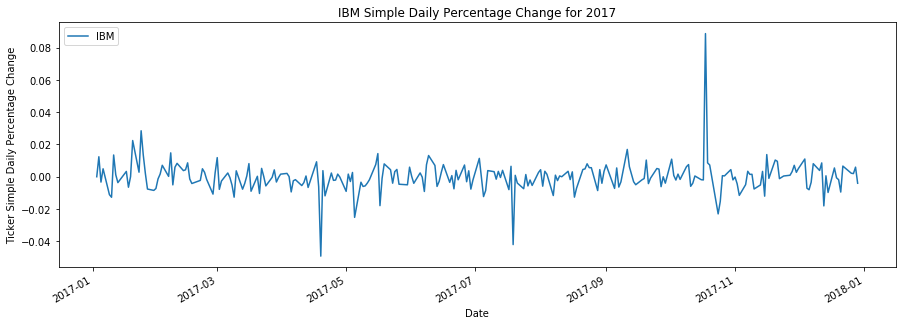

```python
render_dpc(daily_pc, 'IBM')
plt.title('IBM Simple Daily Percentage Change for 2017');
```

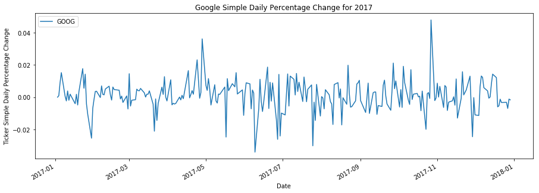

```python
render_dpc(daily_pc, 'GOOG')
plt.title('Google Simple Daily Percentage Change for 2017');
```

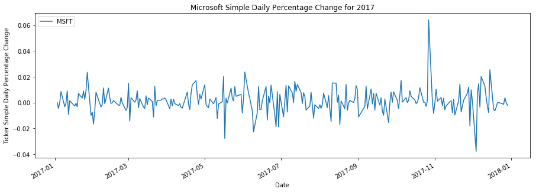

```python
render_dpc(daily_pc, 'MSFT')
plt.title('Microsoft Simple Daily Percentage Change for 2017');
```

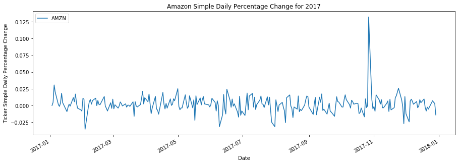

```python
render_dpc(daily_pc, 'AMZN')
plt.title('Amazon Simple Daily Percentage Change for 2017');
```

### Calculate Simple Daily Cumulative Return for our 9 Technology Companies

#### The cumulative daily rate of return is useful to determine the value of an investment at regular intervals after investment.

```python
# calculate simple daily cumulative returns for our 9 tech co
daily_cr = (1 + daily_pc).cumprod()
daily_cr[:5]
```

| Ticker Date | AAPL | ADBE | AMD | FB | FFIV | IBM | GOOG | MSFT | AMZN |
| --- | --- | --- | --- | --- | --- | --- | --- | --- | --- |
| 2017-01-03 | 1.000000 | 1.000000 | 1.000000 | 1.000000 | 1.000000 | 1.000000 | 1.000000 | 1.000000 | 1.000000 |
| 2017-01-04 | 0.998881 | 1.006378 | 1.000000 | 1.015660 | 1.004558 | 1.012381 | 1.000967 | 0.995526 | 1.004657 |
| 2017-01-05 | 1.003960 | 1.023483 | 0.983377 | 1.032603 | 0.997376 | 1.009032 | 1.010024 | 0.995526 | 1.035533 |
| 2017-01-06 | 1.015153 | 1.046579 | 0.990376 | 1.056050 | 0.997583 | 1.013996 | 1.025453 | 1.004155 | 1.056152 |
| 2017-01-09 | 1.024451 | 1.049188 | 1.005249 | 1.068800 | 0.995511 | 1.002751 | 1.026090 | 1.000959 | 1.057386 |

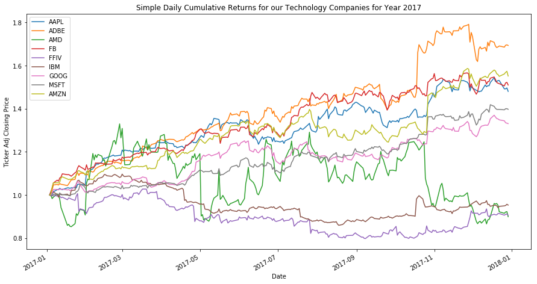

```python
# plot the simple daily cumulative returns for our 9 Technology companies
daily_cr.plot()
plt.title('Simple Daily Cumulative Returns for our Technology Companies for Year 2017')
plt.ylabel('Ticker Adj Closing Price')
plt.legend(loc='best')
plt.gcf().set_size_inches(15, 8);
```

### S&P500 Market Index

#### Use the S&P500 market Index to compare how our 9 selected technology companies faired against the index.

```python
### Get the S&P500 market index file from Yahoo Finance, ^GSPC

### Set time frame for download
### Used to get gspc
start = dt.date(2017, 1, 1)
end = dt.date(2017, 12, 31)

### Get only one ticker
gspc = pdr.get_data_yahoo('^GSPC', start, end)
gspc.to_csv("gspc.csv")
gspc.head()
```

```
[*********************100%***********************]  1 of 1 downloaded
```

| Date | Open | High | Low | Close | Adj Close | Volume |
| --- | --- | --- | --- | --- | --- | --- |
| 2017-01-03 | 2251.570068 | 2263.879883 | 2245.129883 | 2257.830078 | 2257.830078 | 3770530000 |
| 2017-01-04 | 2261.600098 | 2272.820068 | 2261.600098 | 2270.750000 | 2270.750000 | 3764890000 |
| 2017-01-05 | 2268.179932 | 2271.500000 | 2260.449951 | 2269.000000 | 2269.000000 | 3761820000 |
| 2017-01-06 | 2271.139893 | 2282.100098 | 2264.060059 | 2276.979980 | 2276.979980 | 3339890000 |
| 2017-01-09 | 2273.590088 | 2275.489990 | 2268.899902 | 2268.899902 | 2268.899902 | 3217610000 |

```python
sp_500_dpc = gspc['Adj Close'].pct_change().fillna(0)
sp_500_dpc.head()
#sp_500_dpc.tail()
```

```
Date
2017-01-03    0.000000
2017-01-04    0.005722
2017-01-05   -0.000771
2017-01-06    0.003517
2017-01-09   -0.003549
Name: Adj Close, dtype: float64
```

```python
# Add the S&P500 index to our 9 technology companies
dpc_all = pd.concat([sp_500_dpc, daily_pc], axis=1)
dpc_all.rename(columns={'Adj Close': 'S&P500'}, inplace=True)
dpc_all.head()
#dpc_all.tail()
```

| Date | S&P500 | AAPL | ADBE | AMD | FB | FFIV | IBM | GOOG | MSFT | AMZN |
| --- | --- | --- | --- | --- | --- | --- | --- | --- | --- | --- |
| 2017-01-03 | 0.000000 | 0.000000 | 0.000000 | 0.000000 | 0.000000 | 0.000000 | 0.000000 | 0.000000 | 0.000000 | 0.000000 |
| 2017-01-04 | 0.005722 | -0.001119 | 0.006378 | 0.000000 | 0.015660 | 0.004558 | 0.012381 | 0.000967 | -0.004474 | 0.004657 |
| 2017-01-05 | -0.000771 | 0.005085 | 0.016996 | -0.016623 | 0.016682 | -0.007150 | -0.003308 | 0.009048 | 0.000000 | 0.030732 |
| 2017-01-06 | 0.003517 | 0.011148 | 0.022566 | 0.007117 | 0.022707 | 0.000208 | 0.004920 | 0.015277 | 0.008668 | 0.019912 |
| 2017-01-09 | -0.003549 | 0.009159 | 0.002493 | 0.015018 | 0.012074 | -0.002077 | -0.011089 | 0.000620 | -0.003183 | 0.001168 |

### Calculate Cumulative Daily Return and Correlation for our 9 Technology Companies

#### A cumulative return is the aggregate amount an investment has gained or lost over time, independent of the period of time involved.

```python
# Calculate the cumulative daily returns for our selected tech companies
cdr_all = (1 + dpc_all).cumprod()
cdr_all[:5]
```

| Date | S&P500 | AAPL | ADBE | AMD | FB | FFIV | IBM | GOOG | MSFT | AMZN |
| --- | --- | --- | --- | --- | --- | --- | --- | --- | --- | --- |
| 2017-01-03 | 1.000000 | 1.000000 | 1.000000 | 1.000000 | 1.000000 | 1.000000 | 1.000000 | 1.000000 | 1.000000 | 1.000000 |
| 2017-01-04 | 1.005722 | 0.998881 | 1.006378 | 1.000000 | 1.015660 | 1.004558 | 1.012381 | 1.000967 | 0.995526 | 1.004657 |
| 2017-01-05 | 1.004947 | 1.003960 | 1.023483 | 0.983377 | 1.032603 | 0.997376 | 1.009032 | 1.010024 | 0.995526 | 1.035533 |
| 2017-01-06 | 1.008482 | 1.015153 | 1.046579 | 0.990376 | 1.056050 | 0.997583 | 1.013996 | 1.025453 | 1.004155 | 1.056152 |
| 2017-01-09 | 1.004903 | 1.024451 | 1.049188 | 1.005249 | 1.068800 | 0.995511 | 1.002751 | 1.026090 | 1.000959 | 1.057386 |

```python
# Calculate the correlation for the daily percentage change relative to the S&P500 index
dpc_corrs = dpc_all.corr()
dpc_corrs
```

|  | S&P500 | AAPL | ADBE | AMD | FB | FFIV | IBM | GOOG | MSFT | AMZN |
| --- | --- | --- | --- | --- | --- | --- | --- | --- | --- | --- |
| S&P500 | 1.000000 | 0.520813 | 0.397101 | 0.271167 | 0.494691 | 0.381198 | 0.271564 | 0.540292 | 0.587043 | 0.419338 |
| AAPL | 0.520813 | 1.000000 | 0.267549 | 0.308611 | 0.543709 | 0.112568 | -0.010836 | 0.489999 | 0.437547 | 0.509478 |
| ADBE | 0.397101 | 0.267549 | 1.000000 | 0.211920 | 0.440900 | 0.196232 | 0.058161 | 0.431843 | 0.531877 | 0.336805 |
| AMD | 0.271167 | 0.308611 | 0.211920 | 1.000000 | 0.309271 | 0.075464 | 0.019976 | 0.248875 | 0.231428 | 0.242856 |
| FB | 0.494691 | 0.543709 | 0.440900 | 0.309271 | 1.000000 | 0.006873 | -0.013472 | 0.703085 | 0.542453 | 0.654101 |
| FFIV | 0.381198 | 0.112568 | 0.196232 | 0.075464 | 0.006873 | 1.000000 | 0.125874 | 0.150322 | 0.164595 | 0.009195 |
| IBM | 0.271564 | -0.010836 | 0.058161 | 0.019976 | -0.013472 | 0.125874 | 1.000000 | 0.064249 | 0.062395 | 0.001122 |
| GOOG | 0.540292 | 0.489999 | 0.431843 | 0.248875 | 0.703085 | 0.150322 | 0.064249 | 1.000000 | 0.618176 | 0.668582 |
| MSFT | 0.587043 | 0.437547 | 0.531877 | 0.231428 | 0.542453 | 0.164595 | 0.062395 | 0.618176 | 1.000000 | 0.621067 |
| AMZN | 0.419338 | 0.509478 | 0.336805 | 0.242856 | 0.654101 | 0.009195 | 0.001122 | 0.668582 | 0.621067 | 1.000000 |

```python
# Isolate just the correlation of our 9 tech companies relative to the S&P500
dpc_corrs.loc['S&P500']

# Note: From the correlation, MSFT @ 0.5870 had the greatest correlation,
# while AMD @ 0.2715 had the least.
```

```
S&P500    1.000000
AAPL      0.520813
ADBE      0.397101
AMD       0.271167
FB        0.494691
FFIV      0.381198
IBM       0.271564
GOOG      0.540292
MSFT      0.587043
AMZN      0.419338
Name: S&P500, dtype: float64
```

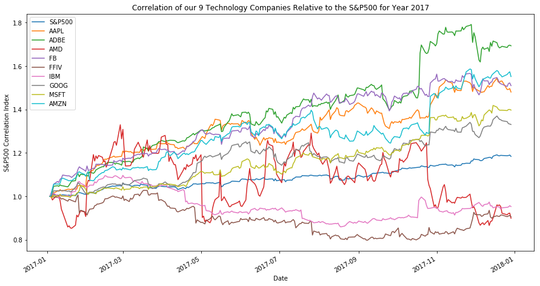

```python
# Plot the correlation of our selected tech companies relative to the S&P500
cdr_all.plot(figsize=(15, 8))
plt.title('Correlation of our 9 Technology Companies Relative to the S&P500 for Year 2017')
plt.ylabel('S&P500 Correlation Index');
```

# Additionally, ADBE, FB, AAPL, AMZN, GOOG, MSFT performed better than the S&P500 index.

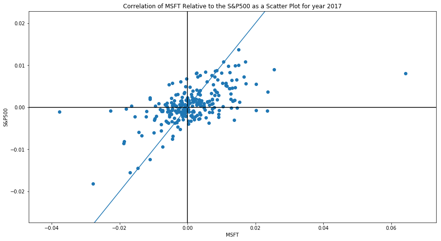

```python
# Plot MSFT correlation to S&P500 as a scatter plot
# MSFT the best correlation
render_scatter_plot(dpc_all, 'MSFT', 'S&P500')
plt.title('Correlation of MSFT Relative to the S&P500 as a Scatter Plot for year 2017');
```

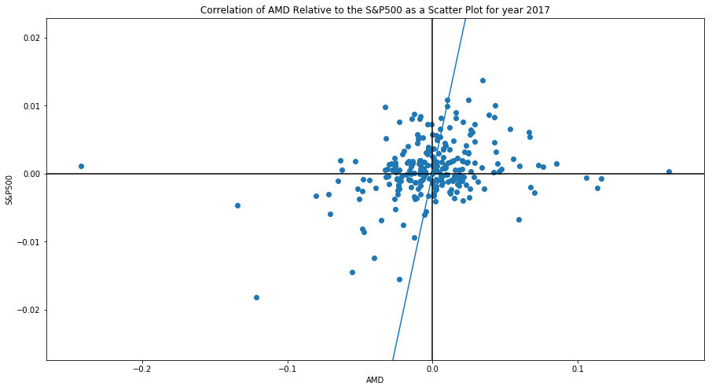

```python
# Plot AMD correlation to S&P500 as a scatter plot
# Had the least correlation
render_scatter_plot(dpc_all, 'AMD', 'S&P500')
plt.title('Correlation of AMD Relative to the S&P500 as a Scatter Plot for year 2017');
```

### Ken Garbutt, July 2018